# Financial Time Series Models (ARCH GARCH)

## Introduction

On this page, I will look to see whether ARCH and GARCH models may be a good fit for the change in intraday range of popular stock market indices. While these models would usually be fitted on the returns of financial intstruments, the day over day change in intraday percent range also exhibits volatility clustering, and intraday range is the exact subject of my project. This means that modelling these time series successfully would be complementary with the other models I have tried to fit, and I am eager to investigate whether these methods will work well at answering my research questions. I will look to fit 3 models: 1 each for the daily range of SPY, QQQ, and IWM.

## Stationarity and Volatility

Load packages

```r
library(tidyverse)
library(forecast)
library(quantmod)
```

Read in data

```r
spyIn <- quantmod::getSymbols("SPY", from = as.Date("2021/01/01"), to = as.Date("2023/09/30"), periodicity = "daily", src = "yahoo", auto.assign = FALSE)
qqqIn <- quantmod::getSymbols("QQQ", from = as.Date("2021/01/01"), to = as.Date("2023/09/30"), periodicity = "daily", src = "yahoo", auto.assign = FALSE)
iwmIn <- quantmod::getSymbols("IWM", from = as.Date("2021/01/01"), to = as.Date("2023/09/30"), periodicity = "daily", src = "yahoo", auto.assign = FALSE)


spyIn$spyRange <- (spyIn$SPY.High - spyIn$SPY.Low)/ spyIn$SPY.Open
qqqIn$qqqRange <- (qqqIn$QQQ.High - qqqIn$QQQ.Low)/ qqqIn$QQQ.Open
iwmIn$iwmRange <- (iwmIn$IWM.High - iwmIn$IWM.Low)/ iwmIn$IWM.Open
```

Plotting the daily ranges:

SPY

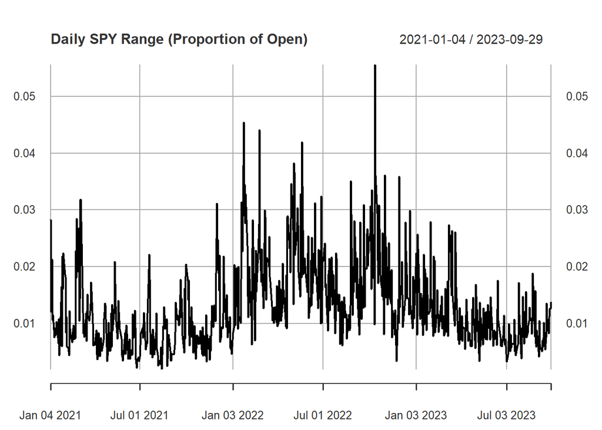

```r
plot(spyIn$spyRange, main = "Daily SPY Range (Proportion of Open)")
```

The SPY data certainly appears to have clustered volatility, as there are large swings in close proximity to eachother. But it also has noticeable trend, with the intraday ranges being higher during the middle of the time series before dropping down again towards the end. To combat this, let’s look at the differenced series:

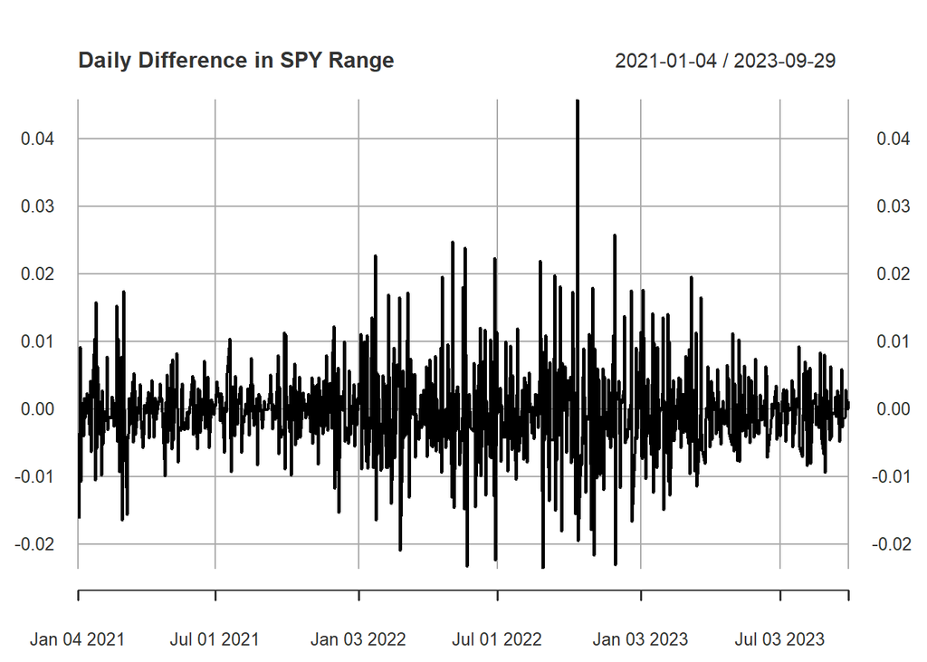

```r
plot(spyIn$spyRange %>% diff(), main = "Daily Difference in SPY Range")
```

Now, we see a plot that looks very similar to the daily returns of a stock and promising for ARCH/GARCH modeling, which means it is stationary but has clustered volatility. To adjust for this, we can fit an ARIMA model on the SPY ranges, and then fit a GARCH model on the residuals, which will come from differenced data that is now stationary.

Repeating the process for QQQ:

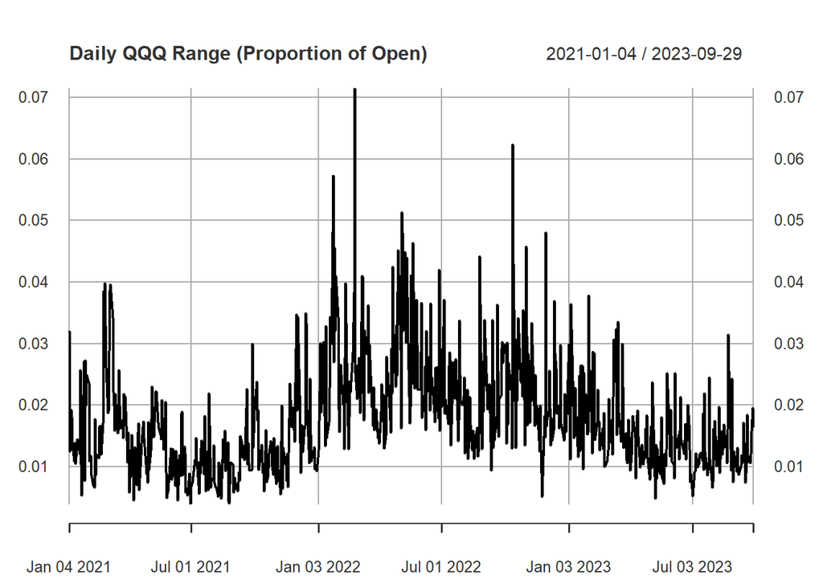

```r
plot(qqqIn$qqqRange, main = "Daily QQQ Range (Proportion of Open)")
```

Once again we see clear non-stationarity in the data, so let’s look at the differenced values:

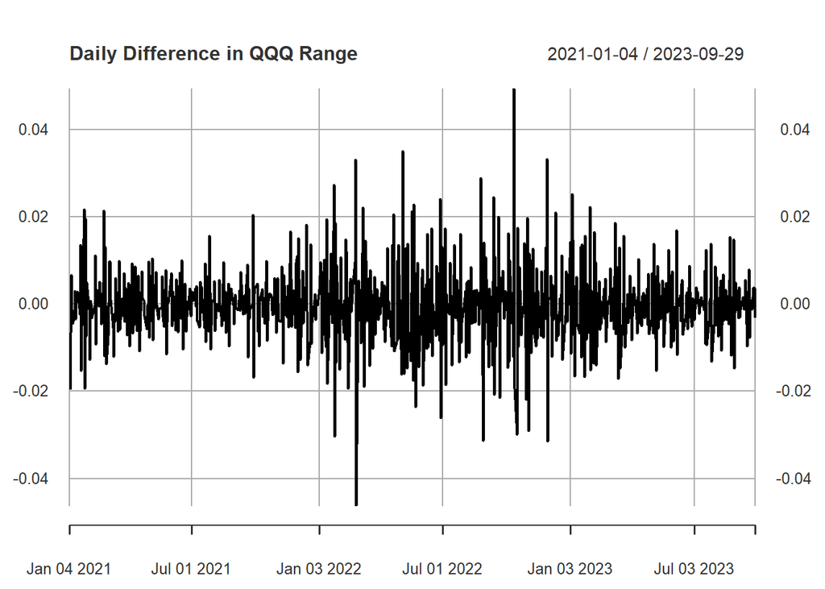

```r
plot(qqqIn$qqqRange %>% diff(), main = "Daily Difference in QQQ Range")
```

Similar to the SPY data, the time series is now stationary, although there is heteroskedasticity. So we might expect to model QQQ and SPY similarly, with an ARIMA + ARCH/GARCH model.

Let’s check IWM:

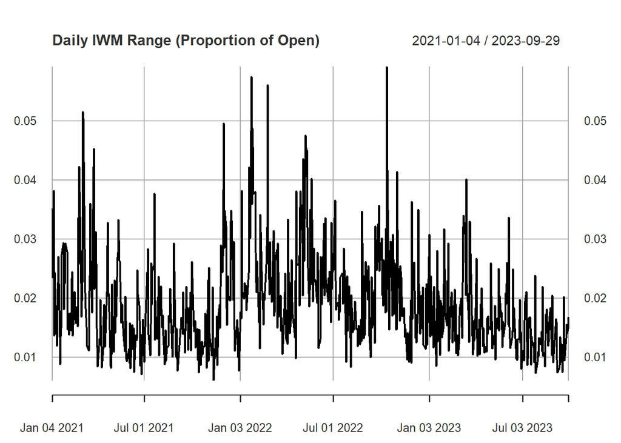

```r
plot(iwmIn$iwmRange, main = "Daily IWM Range (Proportion of Open)")
```

IWM’s intraday range looks slightly more stationary than the other 2 time series, and also has more extreme changes in volatility over time. However, we can still see somewhat of a trend, such that a moving average would be obviously nonstationary, so once again we difference the series.

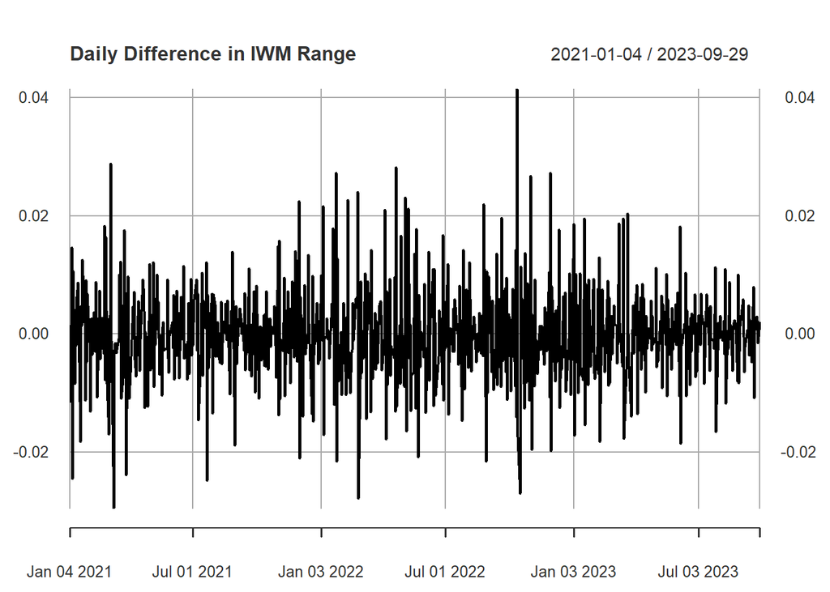

```r
plot(iwmIn$iwmRange %>% diff(), main = "Daily Difference in IWM Range")
```

While the variance looked elevated in the non-differenced plot, it is actually less hesteroskedastic in the differenced plot. This suggests IWM may not have as much autocorrelation in the variance as the other two indices. An ARIMA model alone might suffice here.

## Past ARIMA Models Regerenced

Now, let’s gather ARIMA models for the intraday range. First we declare the helper function

```r
arimaResults <- function(data) {

    i=1
    temp= data.frame()
    ls=matrix(rep(NA,6*100),nrow=100) # roughly nrow = 3x4x2

    for (p in 1:6)# p=1,2,3 : 3
    {
        for(q in 1:6)# q=1,2,3,4 :4
        {
            for(d in 1:2) {

                if(p-1+d - 1+q-1<=8) #usual threshold
                {

                    model<- Arima(data,order=c(p-1,d-1,q-1),include.drift=FALSE)
                    ls[i,]= c(p-1,d-1,q-1,model$aic,model$bic,model$aicc)
                    i=i+1
                    #print(i)

                }

            }

        }
    }

    temp= as.data.frame(ls)
    names(temp)= c("p","d","q","AIC","BIC","AICc")
    return(temp[which.min(temp$AIC),])
    #return(temp)
}
```

Now, let’s find good-fitting models starting with SPY:

```r
arimaResults(spyIn$spyRange)
```

```
   p d q       AIC       BIC      AICc
43 3 0 3 -5139.956 -5103.662 -5139.744
```

The best model returned by the function is ARMA(3,0,3). It is surprising that the models which differenced the data didn’t perform better, but I manually reviewed those options and they all had worse AIC and BIC scores.

For QQQ:

```r
arimaResults(qqqIn$qqqRange)
```

```
   p d q      AIC       BIC      AICc
15 1 0 1 -4814.81 -4796.663 -4814.751
```

For QQQ, the model with the lowest AIC score was ARMA(1,0,1). Once again I expected a differenced model to perform better, but I will continue with the residuals from this model.

For IWM:

```r
arimaResults(iwmIn$iwmRange)
```

```
   p d q       AIC       BIC      AICc
56 4 0 4 -4857.373 -4812.006 -4857.049
```

Fitting the pattern of the best models for the financial instruments being of the form ARMA(N, 0, N), the model with the lowest AIC for IWM was ARMA(4,0,4).

## Reviewing Residuals to Identify ARCH/GARCH Models

Now, lets look at the residuals of all of these models, to identify clustering and see if we need to fit ARCH/GARCH models on the residuals.

Declaring the models

```r
spyARMA <- arima(spyIn$spyRange, order = c(3,0,3))
qqqARMA <- arima(qqqIn$qqqRange, order = c(1,0,1))
iwmARMA <- arima(iwmIn$iwmRange, order = c(4,0,4))
```

SPY range residuals:

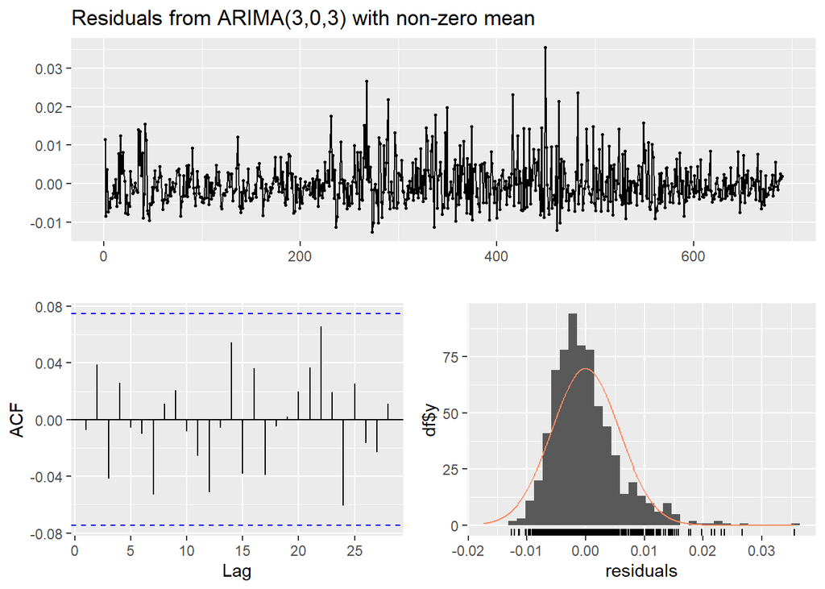

```
    Ljung-Box test

data:  Residuals from ARIMA(3,0,3) with non-zero mean
Q* = 5.2511, df = 4, p-value = 0.2625

Model df: 6.   Total lags used: 10
```

```r
checkresiduals(spyARMA)
```

The residuals show definite clustering around timestamps 260 and 450, which suggests a ARCH/GARCH model will be a good fit. Now lets look at ACF and PACF plots of the residuals and squared residuals:

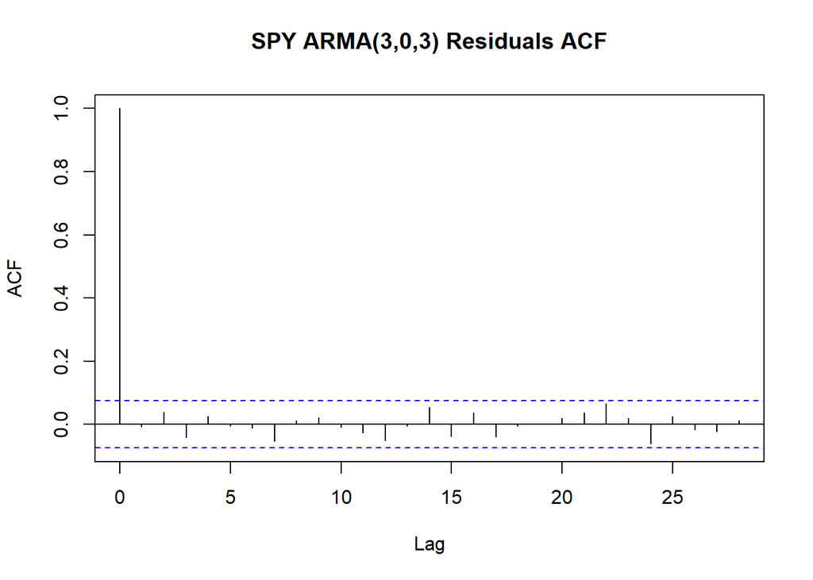

```r
acf(spyARMA$residuals, main = "SPY ARMA(3,0,3) Residuals ACF")
```

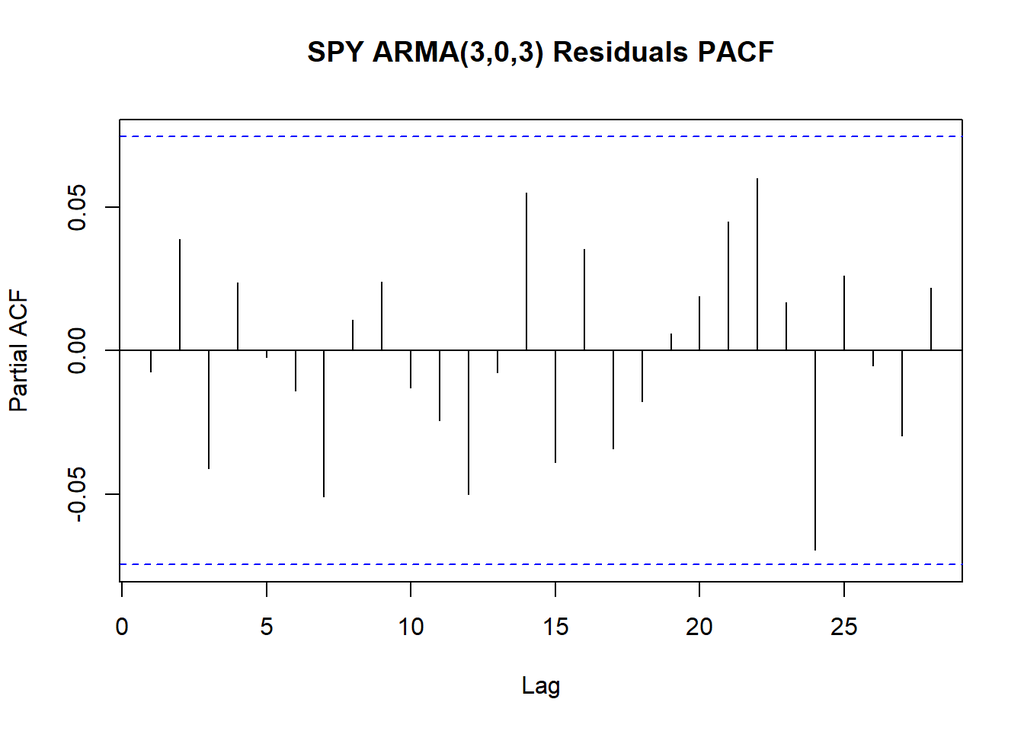

```r
pacf(spyARMA$residuals, main = "SPY ARMA(3,0,3) Residuals PACF")
```

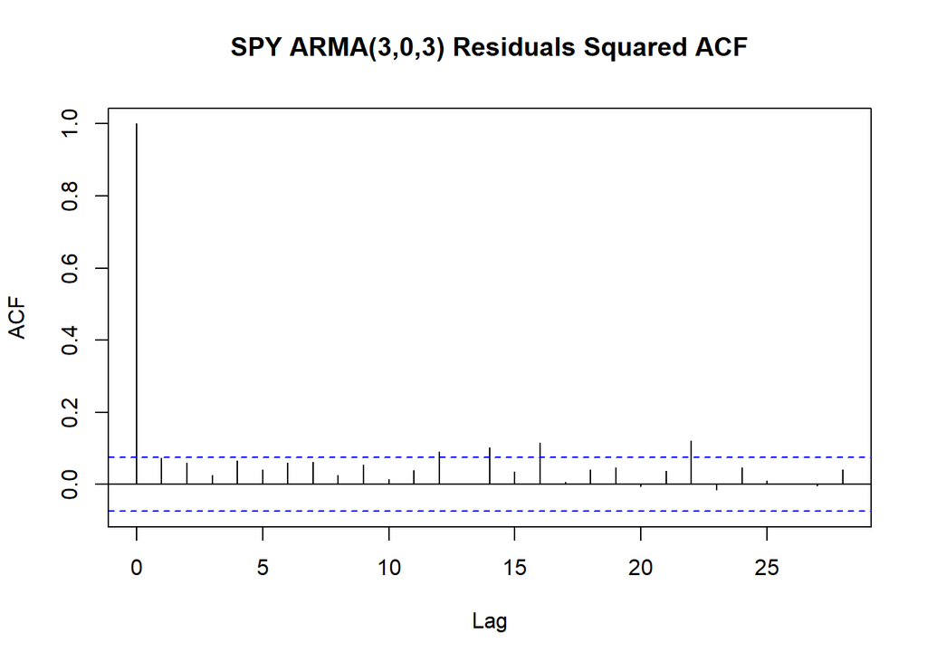

```r
acf(spyARMA$residuals^2, main = "SPY ARMA(3,0,3) Residuals Squared ACF")
```

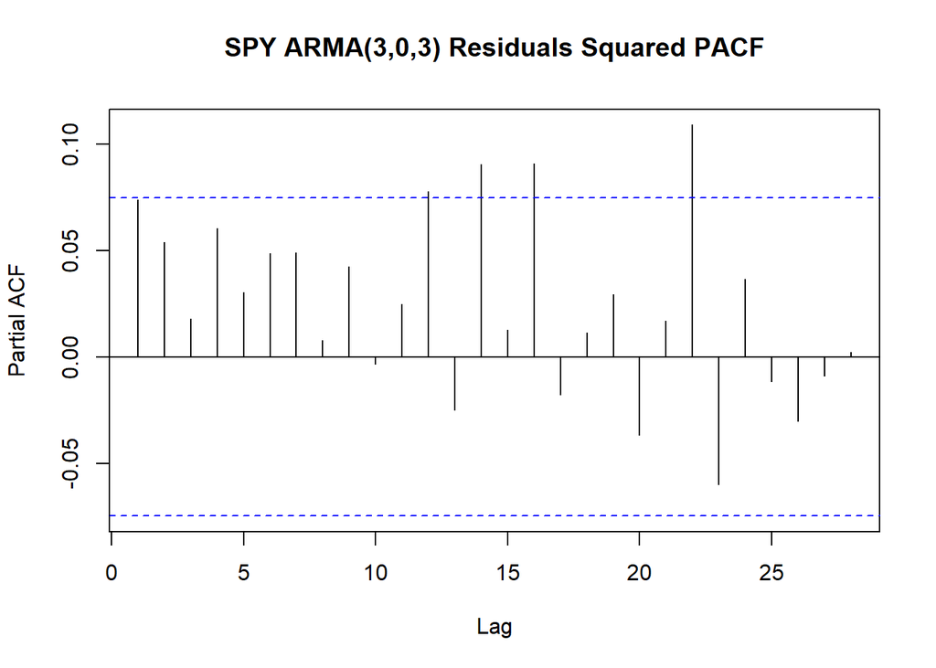

```r
pacf(spyARMA$residuals^2, main = "SPY ARMA(3,0,3) Residuals Squared PACF")
```

```r
#install.packages('FinTS')
library(FinTS)
ArchTest(spyIn$spyRange)
```

```
    ARCH LM-test; Null hypothesis: no ARCH effects

data:  spyIn$spyRange
Chi-squared = 204.01, df = 12, p-value < 2.2e-16
```

```r
#ArchTest(spyARMA$residuals)
```

Based on the ACF and PACF plots, it seems like an ARCH model of (1) might be the best fit for SPY residual data. An ARCH test of the original range data confirms that there is an ARCH effect in the dataset.

QQQ Residuals:

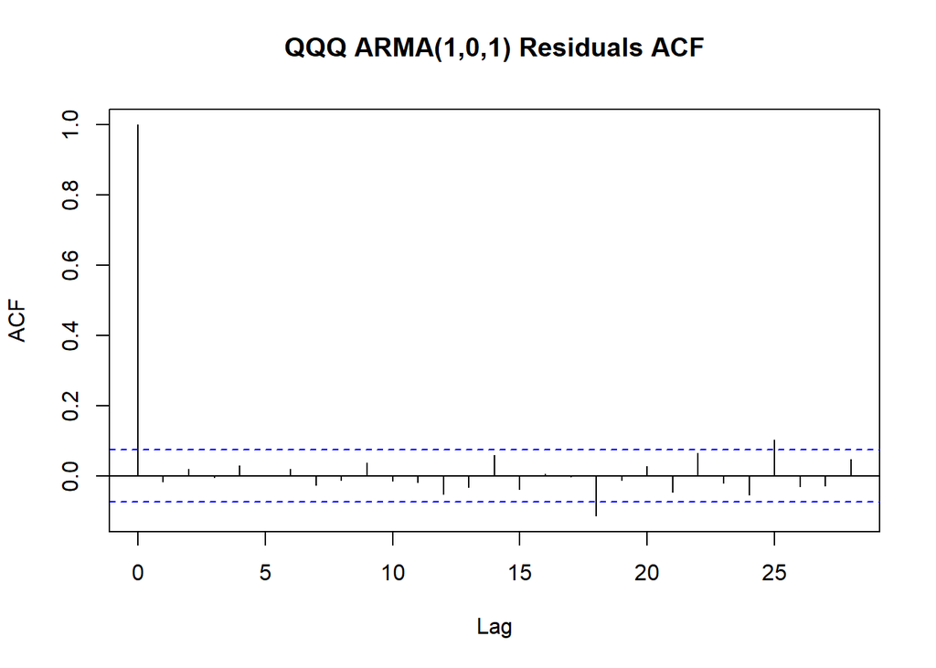

```r
acf(qqqARMA$residuals, main = "QQQ ARMA(1,0,1) Residuals ACF")
```

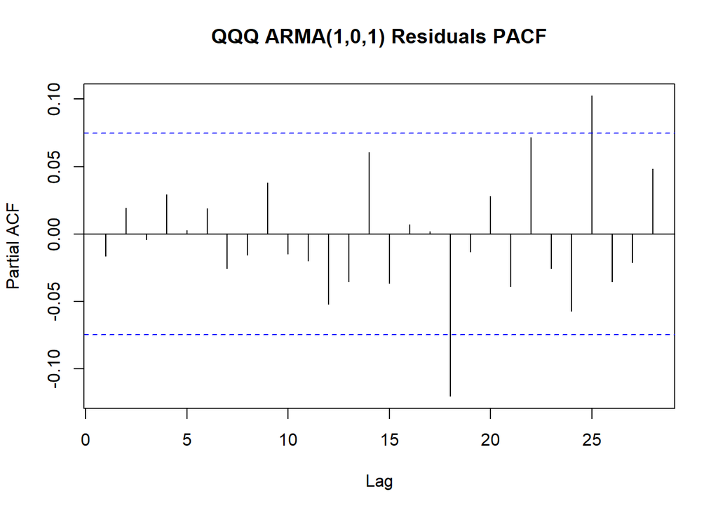

```r
pacf(qqqARMA$residuals, main = "QQQ ARMA(1,0,1) Residuals PACF")
```

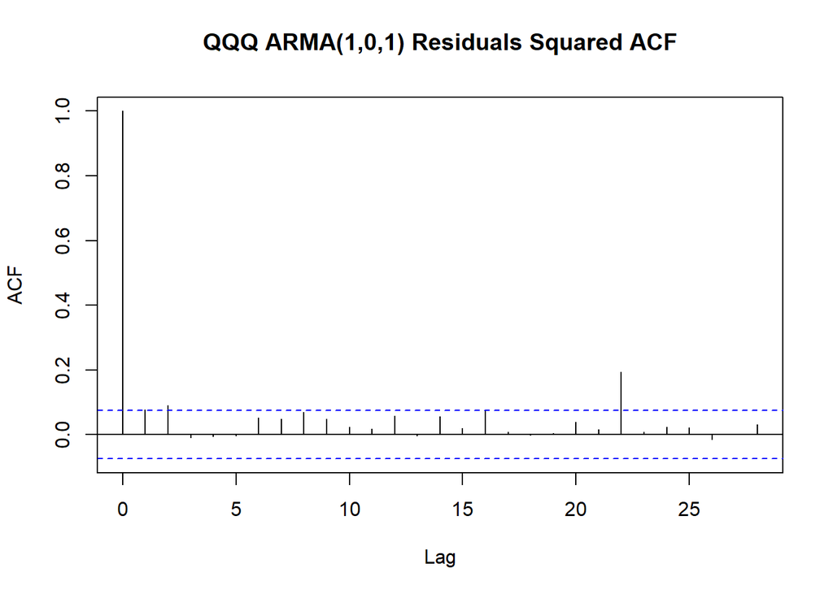

```r
acf(qqqARMA$residuals^2, main = "QQQ ARMA(1,0,1) Residuals Squared ACF")
```

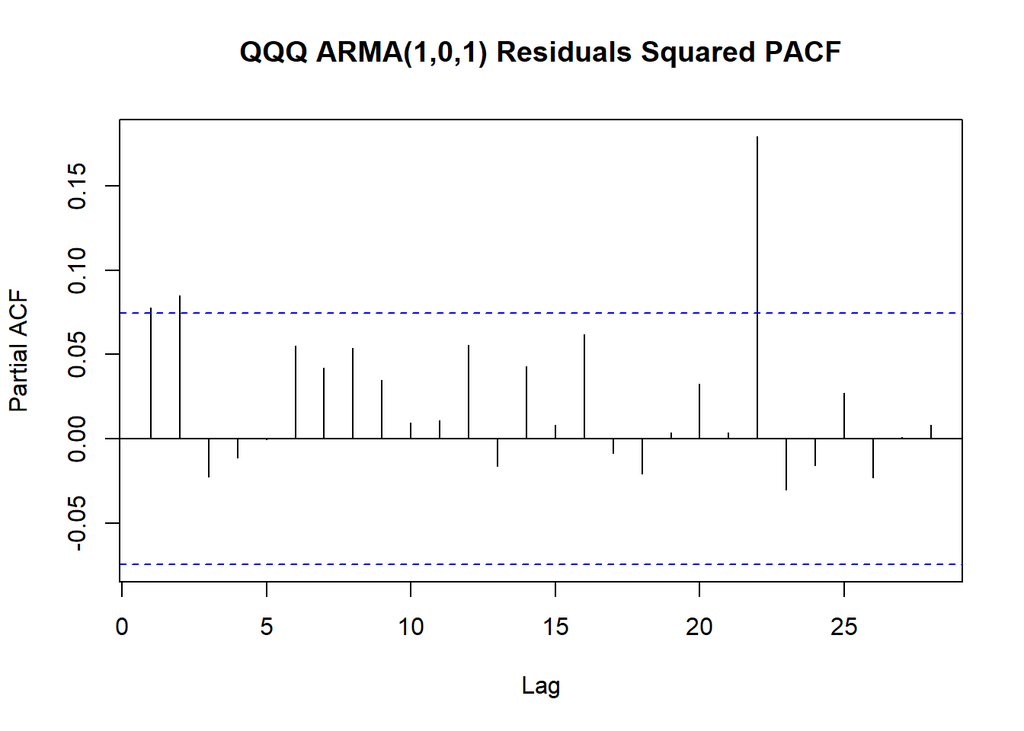

```r
pacf(qqqARMA$residuals^2, main = "QQQ ARMA(1,0,1) Residuals Squared PACF")
```

```r
#install.packages('FinTS')
library(FinTS)
ArchTest(qqqIn$qqqRange)
```

```
    ARCH LM-test; Null hypothesis: no ARCH effects

data:  qqqIn$qqqRange
Chi-squared = 173.7, df = 12, p-value < 2.2e-16
```

```r
ArchTest(qqqARMA$residuals)
```

```
    ARCH LM-test; Null hypothesis: no ARCH effects

data:  qqqARMA$residuals
Chi-squared = 17.618, df = 12, p-value = 0.1278
```

The QQQ residuals suggest GARCH values up to (1,3). The squared residuals suggest more similar to a ARCH(1) model. ARCH tests of the original range data confirm an ARCH effect.

IWM Residuals:

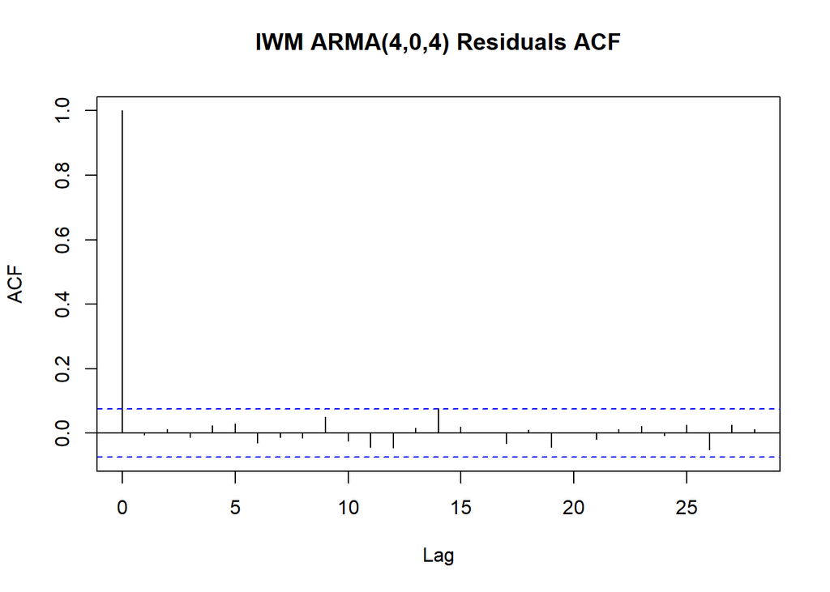

```r
acf(iwmARMA$residuals, main = "IWM ARMA(4,0,4) Residuals ACF")
```

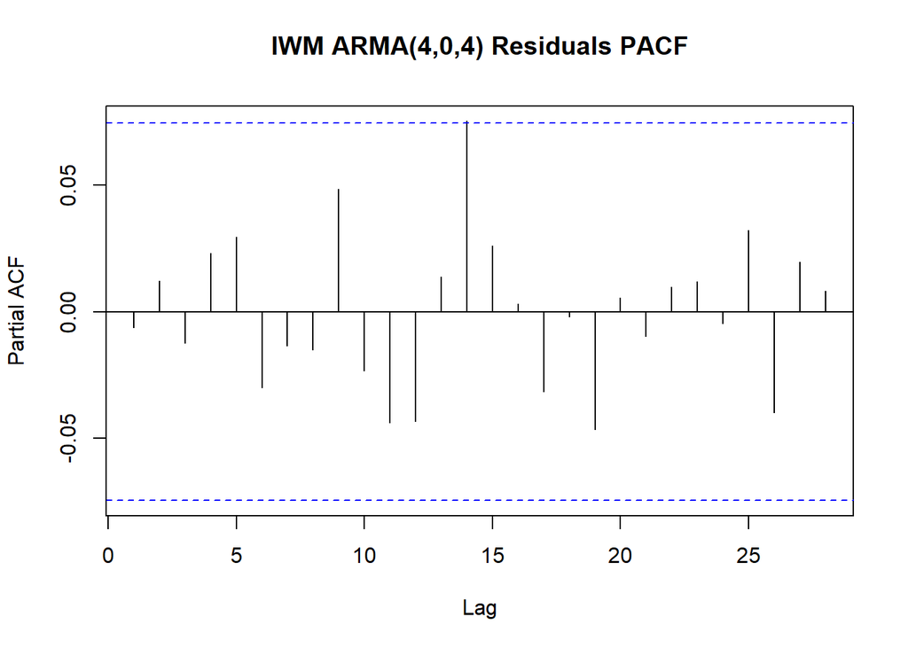

```r
pacf(iwmARMA$residuals, main = "IWM ARMA(4,0,4) Residuals PACF")
```

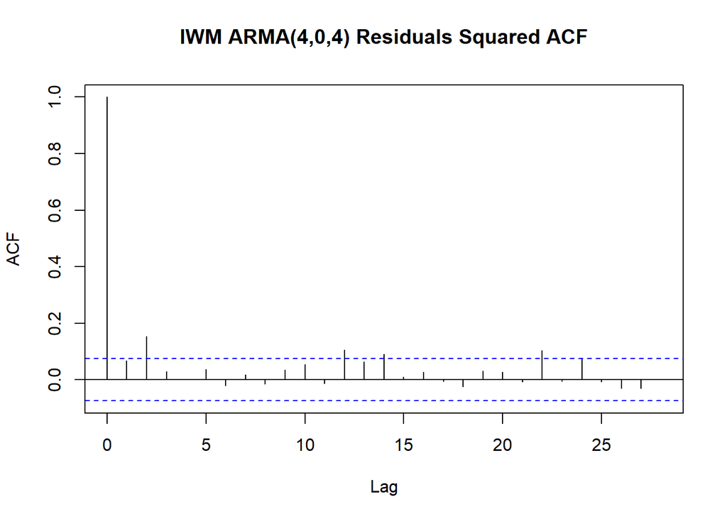

```r
acf(iwmARMA$residuals^2, main = "IWM ARMA(4,0,4) Residuals Squared ACF")
```

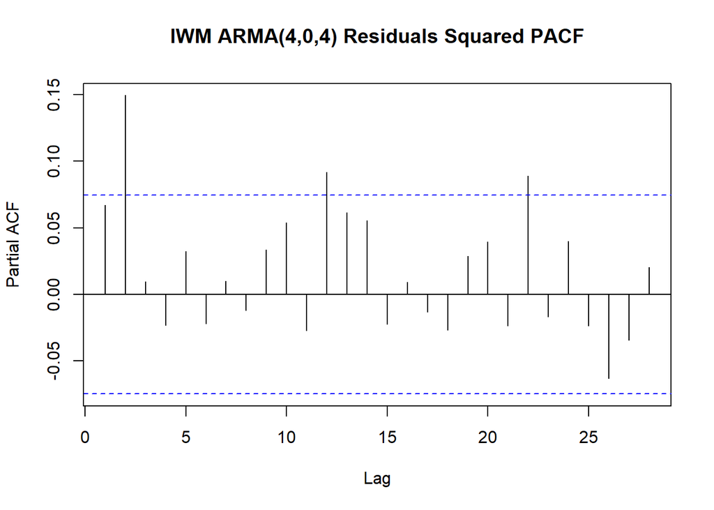

```r
pacf(iwmARMA$residuals^2, main = "IWM ARMA(4,0,4) Residuals Squared PACF")
```

```r
#install.packages('FinTS')
library(FinTS)
ArchTest(iwmIn$iwmRange)
```

```
    ARCH LM-test; Null hypothesis: no ARCH effects

data:  iwmIn$iwmRange
Chi-squared = 174.39, df = 12, p-value < 2.2e-16
```

```r
ArchTest(iwmARMA$residuals)
```

```
    ARCH LM-test; Null hypothesis: no ARCH effects

data:  iwmARMA$residuals
Chi-squared = 28.872, df = 12, p-value = 0.004116
```

The IWM residuals look similar to the spy residuals, but suggest an ARCH (1) model. The squared residuals suggest GARCH(1,1).

## Finding and evaluating ARCH and GARCH Fits

Let’s start by declaring a GARCH helper function that checks possible values:

```r
library(tseries)
garchResults <- function(data) {
    model <- list() ## set counter
    cc <- 1
    for (p in 1:7) {
        for (q in 1:7) {
            if(p + q < 8) {
                model[[cc]] <- garch(data,order=c(q-1,p),trace=F)
                cc <- cc + 1
            }
        }
    }

    ## get AIC values for model evaluation
    GARCH_AIC <- sapply(model, AIC) ## model with lowest AIC is the best
    #which(GARCH_AIC == min(GARCH_AIC))
    ## [1] 24
    model[[which(GARCH_AIC == min(GARCH_AIC))]]
}
```

## SPY GARCH Model Fitting, Diagnostics, and Equation

Let’s check our ARCH(1) model hypothesis for SPY:

```r
library(vars)
library(fGarch)

spyMod <- garchResults(spyARMA$residuals)
summary(spyMod)
```

```
Call:
garch(x = data, order = c(q - 1, p), trace = F)

Model:
GARCH(4,1)

Residuals:
    Min      1Q  Median      3Q     Max
-2.9251 -0.6944 -0.1773  0.4743  5.7716

Coefficient(s):
    Estimate  Std. Error  t value Pr(>|t|)
a0 1.295e-06   5.529e-07    2.342   0.0192 *
a1 2.677e-01   4.417e-02    6.060 1.36e-09 ***
b1 2.309e-01   9.399e-02    2.457   0.0140 *
b2 3.670e-09   1.336e-01    0.000   1.0000
b3 8.880e-02   1.380e-01    0.643   0.5199
b4 4.160e-01   9.804e-02    4.244 2.20e-05 ***
---
Signif. codes:  0 '***' 0.001 '**' 0.01 '*' 0.05 '.' 0.1 ' ' 1

Diagnostic Tests:
    Jarque Bera Test

data:  Residuals
X-squared = 692.91, df = 2, p-value < 2.2e-16


    Box-Ljung test

data:  Squared.Residuals
X-squared = 0.46517, df = 1, p-value = 0.4952
```

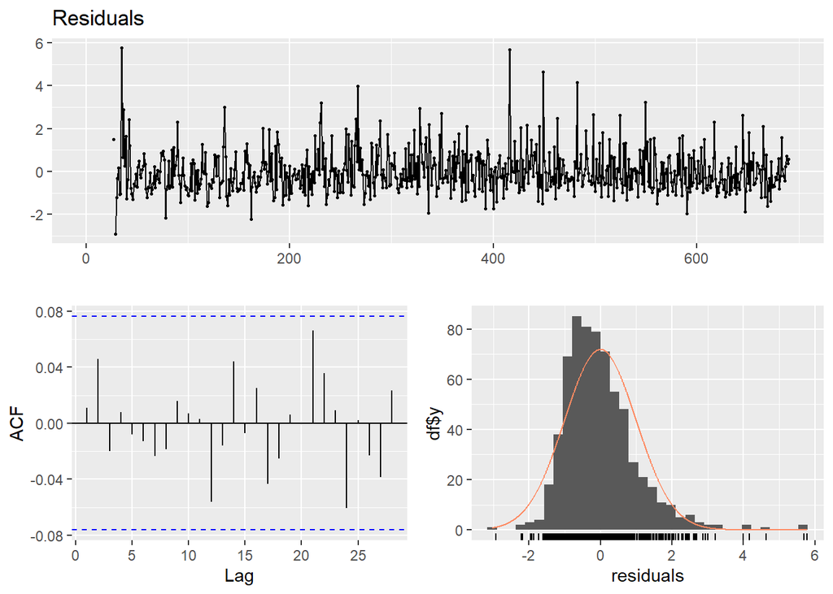

```
    Ljung-Box test

data:  Residuals
Q* = 2.669, df = 10, p-value = 0.9882

Model df: 0.   Total lags used: 10
```

```r
#checkresiduals(spyARMA)
checkresiduals(spyMod)
```

The automatic function returns a surprise: The GARCH model with the lowest AIC is acutally GARCH(4,1). The diagnostics for this model are also promising, the 4th and 1st lag variance are highly significant (p < 0.05), as is the 1st residual error. The Box-Ljung test is decidedly above the threshold at which we can reject the idea that there is no autocorrelation in the residuals (p = 0.495) which is another encouraging sign for the model fit. This suggests that the model has explained most of the signal in the data, with little correlation left in the residuals. It also shows that the results have improved from the ARMA(3,0,3) model alone, which had a Ljung-Box test result of 0.26, which suggests less correlation is left in the residuals after fitting a GARCH(4,1) model.

```r
garchFit(formula = ~arma(3,3) + garch(4,1), data = spyIn$spyRange, trace = FALSE)
```

```
Title:
 GARCH Modelling

Call:
 garchFit(formula = ~arma(3, 3) + garch(4, 1), data = spyIn$spyRange,
    trace = FALSE)

Mean and Variance Equation:
 data ~ arma(3, 3) + garch(4, 1)
<environment: 0x0000000038afa6b8>
 [data = spyIn$spyRange]

Conditional Distribution:
 norm

Coefficient(s):
         mu          ar1          ar2          ar3          ma1          ma2
 2.4917e-05   9.7804e-01   5.9471e-01  -5.7502e-01  -6.6483e-01  -5.8857e-01
        ma3        omega       alpha1       alpha2       alpha3       alpha4
 2.9376e-01   3.2859e-07   5.3270e-02   1.0000e-08   1.0000e-08   1.0000e-08
      beta1
 9.3784e-01

Std. Errors:
 based on Hessian

Error Analysis:
         Estimate  Std. Error  t value Pr(>|t|)
mu      2.492e-05   3.759e-05    0.663 0.507405
ar1     9.780e-01   1.474e-01    6.634 3.28e-11 ***
ar2     5.947e-01   1.858e-01    3.200 0.001374 **
ar3    -5.750e-01   8.150e-02   -7.055 1.73e-12 ***
ma1    -6.648e-01   1.629e-01   -4.082 4.46e-05 ***
ma2    -5.886e-01   1.573e-01   -3.742 0.000182 ***
ma3     2.938e-01   8.403e-02    3.496 0.000473 ***
omega   3.286e-07   2.829e-07    1.161 0.245454
alpha1  5.327e-02   4.160e-02    1.281 0.200369
alpha2  1.000e-08   4.400e-02    0.000 1.000000
alpha3  1.000e-08   1.060e-01    0.000 1.000000
alpha4  1.000e-08   8.994e-02    0.000 1.000000
beta1   9.378e-01   2.959e-02   31.699  < 2e-16 ***
---
Signif. codes:  0 '***' 0.001 '**' 0.01 '*' 0.05 '.' 0.1 ' ' 1

Log Likelihood:
 2619.748    normalized:  3.796736

Description:
 Thu Dec 07 01:56:28 2023 by user: corwi
```

The final evaluation of all the parameters together, however, suggests that the GARCH model should be (0,1). SO I will write the final correct formula as:

Final formula is: Rt = 0.000025 + 0.978 * R(t-1) + 0.595 * R(t-2) - 0.575 * R(t-3) - 0.665 * W(t-1) - 0.589 * W(t-2) + 0.294 * W(t-3) + At

At = Sigma(t) * Epsilon(t)

Sigma(t) ^ 2 = 0.00000033 + 0.94 * Sigma(t-1)^2

## QQQ GARCH Model Fitting, Diagnostics, and Equation

```r
qqqMod <- garchResults(qqqARMA$residuals)
summary(qqqMod)
```

```
Call:
garch(x = data, order = c(q - 1, p), trace = F)

Model:
GARCH(1,1)

Residuals:
    Min      1Q  Median      3Q     Max
-1.9569 -0.6967 -0.1981  0.4453  5.4864

Coefficient(s):
    Estimate  Std. Error  t value Pr(>|t|)
a0 3.515e-07   1.633e-07    2.152   0.0314 *
a1 3.527e-02   5.331e-03    6.615 3.72e-11 ***
b1 9.582e-01   6.218e-03  154.113  < 2e-16 ***
---
Signif. codes:  0 '***' 0.001 '**' 0.01 '*' 0.05 '.' 0.1 ' ' 1

Diagnostic Tests:
    Jarque Bera Test

data:  Residuals
X-squared = 591.42, df = 2, p-value < 2.2e-16


    Box-Ljung test

data:  Squared.Residuals
X-squared = 0.070318, df = 1, p-value = 0.7909
```

```r
#qqqMod

#checkresiduals(qqqARMA)
#checkresiduals(qqqMod)
```

```r
garchFit(formula = ~arma(1,1) + garch(1,1), data = qqqIn$qqqRange, trace = FALSE)
```

```
Title:
 GARCH Modelling

Call:
 garchFit(formula = ~arma(1, 1) + garch(1, 1), data = qqqIn$qqqRange,
    trace = FALSE)

Mean and Variance Equation:
 data ~ arma(1, 1) + garch(1, 1)
<environment: 0x000000003acec0c8>
 [data = qqqIn$qqqRange]

Conditional Distribution:
 norm

Coefficient(s):
         mu          ar1          ma1        omega       alpha1        beta1
 6.1100e-04   9.6203e-01  -7.4073e-01   3.5130e-07   3.5178e-02   9.5819e-01

Std. Errors:
 based on Hessian

Error Analysis:
         Estimate  Std. Error  t value Pr(>|t|)
mu      6.110e-04   2.413e-04    2.532   0.0113 *
ar1     9.620e-01   1.488e-02   64.636  < 2e-16 ***
ma1    -7.407e-01   3.685e-02  -20.099  < 2e-16 ***
omega   3.513e-07   2.017e-07    1.741   0.0816 .
alpha1  3.518e-02   7.556e-03    4.656 3.23e-06 ***
beta1   9.582e-01   7.993e-03  119.873  < 2e-16 ***
---
Signif. codes:  0 '***' 0.001 '**' 0.01 '*' 0.05 '.' 0.1 ' ' 1

Log Likelihood:
 2441.621    normalized:  3.538581

Description:
 Thu Dec 07 01:56:28 2023 by user: corwi
```

Final formula is: Rt = 0.00061 + 0.962 * R(t-1) - 0.741 * W(t-1) + At

At = Sigma(t) * Epsilon(t)

Sigma(t) ^ 2 = 0.00000035 + .034 * a(t-1)^2 + 0.96 * Sigma(t-1)^2

## IWM GARCH Model Fitting, Diagnostics, and Equation

```r
iwmMod <- garchResults(iwmARMA$residuals)
summary(iwmMod)
```

```
Call:
garch(x = data, order = c(q - 1, p), trace = F)

Model:
GARCH(1,1)

Residuals:
    Min      1Q  Median      3Q     Max
-1.7824 -0.7249 -0.1962  0.4915  5.1795

Coefficient(s):
    Estimate  Std. Error  t value Pr(>|t|)
a0 2.153e-06   8.987e-07    2.395 0.016602 *
a1 6.089e-02   1.693e-02    3.597 0.000322 ***
b1 8.969e-01   2.903e-02   30.900  < 2e-16 ***
---
Signif. codes:  0 '***' 0.001 '**' 0.01 '*' 0.05 '.' 0.1 ' ' 1

Diagnostic Tests:
    Jarque Bera Test

data:  Residuals
X-squared = 338.27, df = 2, p-value < 2.2e-16


    Box-Ljung test

data:  Squared.Residuals
X-squared = 8.6335e-05, df = 1, p-value = 0.9926
```

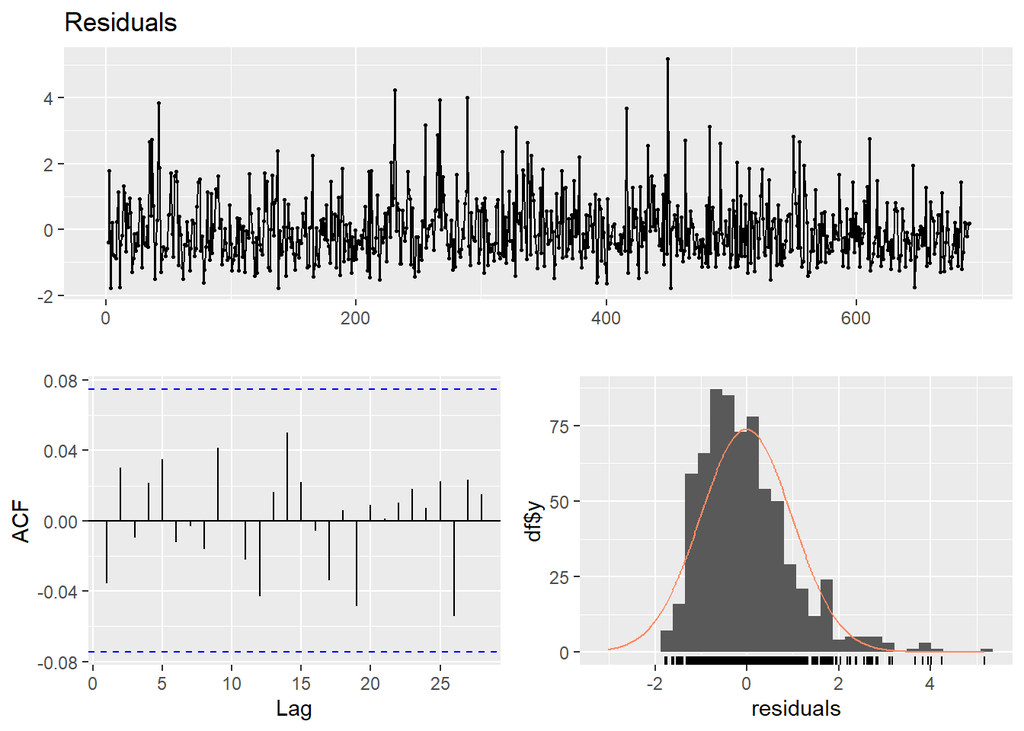

```
    Ljung-Box test

data:  Residuals
Q* = 4.2445, df = 10, p-value = 0.9356

Model df: 0.   Total lags used: 10
```

```r
# checkresiduals(iwmARMA)

checkresiduals(iwmMod)
```

```r
garchFit(formula = ~arma(4,2) + garch(1,1), data = iwmIn$iwmRange, trace = FALSE)
```

```
Title:
 GARCH Modelling

Call:
 garchFit(formula = ~arma(4, 2) + garch(1, 1), data = iwmIn$iwmRange,
    trace = FALSE)

Mean and Variance Equation:
 data ~ arma(4, 2) + garch(1, 1)
<environment: 0x000000002d7fd900>
 [data = iwmIn$iwmRange]

Conditional Distribution:
 norm

Coefficient(s):
         mu          ar1          ar2          ar3          ar4          ma1
 3.4855e-04   6.6410e-01   5.6820e-01  -1.7672e-01  -7.5180e-02  -3.9551e-01
        ma2        omega       alpha1        beta1
-4.7133e-01   1.7350e-06   5.8615e-02   9.0767e-01

Std. Errors:
 based on Hessian

Error Analysis:
         Estimate  Std. Error  t value Pr(>|t|)
mu      3.485e-04   3.509e-04    0.993  0.32058
ar1     6.641e-01   1.613e-01    4.118 3.83e-05 ***
ar2     5.682e-01   2.229e-01    2.549  0.01080 *
ar3    -1.767e-01   5.433e-02   -3.253  0.00114 **
ar4    -7.518e-02   6.747e-02   -1.114  0.26516
ma1    -3.955e-01   1.592e-01   -2.484  0.01299 *
ma2    -4.713e-01   1.791e-01   -2.631  0.00851 **
omega   1.735e-06   1.000e-06    1.734  0.08287 .
alpha1  5.861e-02   1.936e-02    3.027  0.00247 **
beta1   9.077e-01   3.244e-02   27.979  < 2e-16 ***
---
Signif. codes:  0 '***' 0.001 '**' 0.01 '*' 0.05 '.' 0.1 ' ' 1

Log Likelihood:
 2457.18    normalized:  3.56113

Description:
 Thu Dec 07 01:56:29 2023 by user: corwi
```

Final formula is: Rt = 0.00035 + 0.664 * R(t-1) + 0.568 * R(t-2) - 0.177 * R(t-3) - 0.075 * R(t-4) - 0.396 * W(t-1) - 0.471 * W(t-2) + At

At = Sigma(t) * Epsilon(t)